# Exploratory Data Analysis for Health Professionals

Sergio Uribe

# Introduction

Este libro está escrito por un dentista investigador para dentistas investigadores. Uno de los problemas que tenemos los investigadores es que a veces se crea una brecha entre quienes generamos preguntas y los datos y quienes realizan el análisis. Y con el advenimiento de computadoras más potentes, existe la tentación de usar exóticos modelos estadísticos que son difíciles de comprender y más aun de interpretar. Sin embargo, una buena investigación, o sea aquella con una pregunta clara, un diseño apropiado y una recolección honesta de datos debería

Dejar que los datos hablen. Los datos tienen una historia y debemos dejar que nos la cuenten.

EL investigador dental puede no conocer los detalles del modelado estadístico, pero debería conocer y manejar las técnicas de análisis exploratorio de datos. Espero que este libro ayude a los investigadores con esta crucial tarea: el análisis exploratorio de datos (EDA).

# Packages

- [tidyverse](http://r4ds.had.co.nz/)
- [NHANES](https://cran.r-project.org/web/packages/NHANES/index.html)
- [skimr](https://cran.r-project.org/web/packages/skimr/index.html)
- [gmodels](https://cran.r-project.org/web/packages/gmodels/index.html)
- visdat

```r
library(tidyverse)
```

Data from NHANES

```r
install.packages("NHANES")
```

# EDA

## Dataframe EDA

### Basic EDA

Explore the dataset (opens a new window)

```r
dim(NHANES)
```

[output not shown]

```r
cname
```

```
Error: object 'cname' not found
```

```r
View(NHANES)
```

View numbers of rows and columns

View names of columns

```r
colnames(NHANES)
```

```
 [1] "ID"               "SurveyYr"         "Gender"
 [4] "Age"              "AgeDecade"        "AgeMonths"
 [7] "Race1"            "Race3"            "Education"
[10] "MaritalStatus"    "HHIncome"         "HHIncomeMid"
[13] "Poverty"          "HomeRooms"        "HomeOwn"
[16] "Work"             "Weight"           "Length"
[19] "HeadCirc"         "Height"           "BMI"
[22] "BMICatUnder20yrs" "BMI_WHO"          "Pulse"
[25] "BPSysAve"         "BPDiaAve"         "BPSys1"
[28] "BPDia1"           "BPSys2"           "BPDia2"
[31] "BPSys3"           "BPDia3"           "Testosterone"
[34] "DirectChol"       "TotChol"          "UrineVol1"
[37] "UrineFlow1"       "UrineVol2"        "UrineFlow2"
[40] "Diabetes"         "DiabetesAge"      "HealthGen"
[43] "DaysPhysHlthBad"  "DaysMentHlthBad"  "LittleInterest"
[46] "Depressed"        "nPregnancies"     "nBabies"
[49] "Age1stBaby"       "SleepHrsNight"    "SleepTrouble"
[52] "PhysActive"       "PhysActiveDays"   "TVHrsDay"
[55] "CompHrsDay"       "TVHrsDayChild"    "CompHrsDayChild"
[58] "Alcohol12PlusYr"  "AlcoholDay"       "AlcoholYear"
[61] "SmokeNow"         "Smoke100"         "Smoke100n"
[64] "SmokeAge"         "Marijuana"        "AgeFirstMarij"
[67] "RegularMarij"     "AgeRegMarij"      "HardDrugs"
[70] "SexEver"          "SexAge"           "SexNumPartnLife"
[73] "SexNumPartYear"   "SameSex"          "SexOrientation"
[76] "PregnantNow"
```

first 6 rows

| ID | SurveyYr | Gender | Age | AgeDecade | AgeMonths | Race1 | Race3 | Education | MaritalStatus | HHIncome | HHIncomeMid | Poverty | HomeRooms | HomeOwn | Work | Weight | Length | HeadCirc | Height | BMI | BMICatUnder20yrs | BMI_WHO | Pulse | BPSysAve | BPDiaAve | BPSys1 | BPDia1 | BPSys2 | BPDia2 | … |
| --- | --- | --- | --- | --- | --- | --- | --- | --- | --- | --- | --- | --- | --- | --- | --- | --- | --- | --- | --- | --- | --- | --- | --- | --- | --- | --- | --- | --- | --- | --- |
| 51624 | 2009_10 | male | 34 | 30-39 | 409 | White | NA | High School | Married | 25000-34999 | 30000 | 1.36 | 6 | Own | NotWorking | 87.4 | NA | NA | 164.7 | 32.22 | NA | 30.0_plus | 70 | 113 | 85 | 114 | 88 | 114 | 88 | … |
| 51624 | 2009_10 | male | 34 | 30-39 | 409 | White | NA | High School | Married | 25000-34999 | 30000 | 1.36 | 6 | Own | NotWorking | 87.4 | NA | NA | 164.7 | 32.22 | NA | 30.0_plus | 70 | 113 | 85 | 114 | 88 | 114 | 88 | … |
| 51624 | 2009_10 | male | 34 | 30-39 | 409 | White | NA | High School | Married | 25000-34999 | 30000 | 1.36 | 6 | Own | NotWorking | 87.4 | NA | NA | 164.7 | 32.22 | NA | 30.0_plus | 70 | 113 | 85 | 114 | 88 | 114 | 88 | … |
| 51625 | 2009_10 | male | 4 | 0-9 | 49 | Other | NA | NA | NA | 20000-24999 | 22500 | 1.07 | 9 | Own | NA | 17.0 | NA | NA | 105.4 | 15.30 | NA | 12.0_18.5 | NA | NA | NA | NA | NA | NA | NA | … |
| 51630 | 2009_10 | female | 49 | 40-49 | 596 | White | NA | Some College | LivePartner | 35000-44999 | 40000 | 1.91 | 5 | Rent | NotWorking | 86.7 | NA | NA | 168.4 | 30.57 | NA | 30.0_plus | 86 | 112 | 75 | 118 | 82 | 108 | 74 | … |
| 51638 | 2009_10 | male | 9 | 0-9 | 115 | White | NA | NA | NA | 75000-99999 | 87500 | 1.84 | 6 | Rent | NA | 29.8 | NA | NA | 133.1 | 16.82 | NA | 12.0_18.5 | 82 | 86 | 47 | 84 | 50 | 84 | 50 | … |

Try `tail(NHANES)` to see last 6 rows

```r
glimpse(NHANES)
```

```
Observations: 10,000
Variables: 76
$ ID               <int> 51624, 51624, 51624, 51625, 51630, 51638, 51646, ...
$ SurveyYr         <fctr> 2009_10, 2009_10, 2009_10, 2009_10, 2009_10, 200...
$ Gender           <fctr> male, male, male, male, female, male, male, fema...
$ Age              <int> 34, 34, 34, 4, 49, 9, 8, 45, 45, 45, 66, 58, 54, ...
$ AgeDecade        <fctr>  30-39,  30-39,  30-39,  0-9,  40-49,  0-9,  0-9...
$ AgeMonths        <int> 409, 409, 409, 49, 596, 115, 101, 541, 541, 541, ...
$ Race1            <fctr> White, White, White, Other, White, White, White,...
$ Race3            <fctr> NA, NA, NA, NA, NA, NA, NA, NA, NA, NA, NA, NA, ...
$ Education        <fctr> High School, High School, High School, NA, Some ...
$ MaritalStatus    <fctr> Married, Married, Married, NA, LivePartner, NA, ...
$ HHIncome         <fctr> 25000-34999, 25000-34999, 25000-34999, 20000-249...
$ HHIncomeMid      <int> 30000, 30000, 30000, 22500, 40000, 87500, 60000, ...
$ Poverty          <dbl> 1.36, 1.36, 1.36, 1.07, 1.91, 1.84, 2.33, 5.00, 5...
```

[output cut: 63 more lines]

```r
summary(NHANES)
```

```
       ID           SurveyYr       Gender          Age          AgeDecade
 Min.   :51624   2009_10:5000   female:5020   Min.   : 0.00    40-49 :1398
 1st Qu.:56905   2011_12:5000   male  :4980   1st Qu.:17.00    0-9   :1391
 Median :62160                                Median :36.00    10-19 :1374
 Mean   :61945                                Mean   :36.74    20-29 :1356
 3rd Qu.:67039                                3rd Qu.:54.00    30-39 :1338
 Max.   :71915                                Max.   :80.00   (Other):2810
                                                              NA's   : 333
   AgeMonths          Race1           Race3               Education
 Min.   :  0.0   Black   :1197   Asian   : 288   8th Grade     : 451
 1st Qu.:199.0   Hispanic: 610   Black   : 589   9 - 11th Grade: 888
 Median :418.0   Mexican :1015   Hispanic: 350   High School   :1517
 Mean   :420.1   White   :6372   Mexican : 480   Some College  :2267
 3rd Qu.:624.0   Other   : 806   White   :3135   College Grad  :2098
 Max.   :959.0                   Other   : 158   NA's          :2779
 NA's   :5038                    NA's    :5000
      MaritalStatus         HHIncome     HHIncomeMid        Poverty
 Divorced    : 707   more 99999 :2220   Min.   :  2500   Min.   :0.000
 LivePartner : 560   75000-99999:1084   1st Qu.: 30000   1st Qu.:1.240
 Married     :3945   25000-34999: 958   Median : 50000   Median :2.700
 NeverMarried:1380   35000-44999: 863   Mean   : 57206   Mean   :2.802
 Separated   : 183   45000-54999: 784   3rd Qu.: 87500   3rd Qu.:4.710
 Widowed     : 456   (Other)    :3280   Max.   :100000   Max.   :5.000
 NA's        :2769   NA's       : 811   NA's   :811      NA's   :726
   HomeRooms       HomeOwn             Work          Weight
 Min.   : 1.000   Own  :6425   Looking   : 311   Min.   :  2.80
 1st Qu.: 5.000   Rent :3287   NotWorking:2847   1st Qu.: 56.10
 Median : 6.000   Other: 225   Working   :4613   Median : 72.70
 Mean   : 6.249   NA's :  63   NA's      :2229   Mean   : 70.98
 3rd Qu.: 8.000                                  3rd Qu.: 88.90
 Max.   :13.000                                  Max.   :230.70
 NA's   :69                                      NA's   :78
     Length          HeadCirc         Height           BMI
 Min.   : 47.10   Min.   :34.20   Min.   : 83.6   Min.   :12.88
 1st Qu.: 75.70   1st Qu.:39.58   1st Qu.:156.8   1st Qu.:21.58
 Median : 87.00   Median :41.45   Median :166.0   Median :25.98
 Mean   : 85.02   Mean   :41.18   Mean   :161.9   Mean   :26.66
 3rd Qu.: 96.10   3rd Qu.:42.92   3rd Qu.:174.5   3rd Qu.:30.89
 Max.   :112.20   Max.   :45.40   Max.   :200.4   Max.   :81.25
 NA's   :9457     NA's   :9912    NA's   :353     NA's   :366
```

[output cut: 86 more lines]

```
             Max.   :48.00                Max.   :52.00
             NA's   :7109                 NA's   :8634
 SexEver         SexAge      SexNumPartnLife   SexNumPartYear   SameSex
 No  : 223   Min.   : 9.00   Min.   :   0.00   Min.   : 0.000   No  :5353
 Yes :5544   1st Qu.:15.00   1st Qu.:   2.00   1st Qu.: 1.000   Yes : 415
 NA's:4233   Median :17.00   Median :   5.00   Median : 1.000   NA's:4232
             Mean   :17.43   Mean   :  15.09   Mean   : 1.342
             3rd Qu.:19.00   3rd Qu.:  12.00   3rd Qu.: 1.000
             Max.   :50.00   Max.   :2000.00   Max.   :69.000
             NA's   :4460    NA's   :4275      NA's   :5072
      SexOrientation  PregnantNow
 Bisexual    : 119   Yes    :  72
 Heterosexual:4638   No     :1573
 Homosexual  :  85   Unknown:  51
 NA's        :5158   NA's   :8304
```

Leave only one year

```r
NHANES <- NHANES %>%
        filter(SurveyYr == 2011_12)
```

[output not shown]

```r
dim(NHANES)
```

```
[1] 5000   76
```

#### Skim package for EDA

```r
library(skimr)
```

```r
skim(NHANES)
```

```
Skim summary statistics
 n obs: 5000
 n variables: 76

Variable type: factor
         variable missing complete    n n_unique                                           top_counts ordered
        AgeDecade     177     4823 5000        8     0-: 709,  10: 704,  50: 690,  20: 672              FALSE
  Alcohol12PlusYr    1650     3350 5000        2              Yes: 2657, NA: 1650, No: 693              FALSE
          BMI_WHO     179     4821 5000        4                                        18.: 1487, 30   FALSE
 BMICatUnder20yrs    3726     1274 5000        4    NA: 3726, Nor: 805, Obe: 221, Ove: 193              FALSE
       CompHrsDay     137     4863 5000        7 0_t: 1409, 0_h: 1073, 1_h: 1030, 2_h: 589              FALSE
        Depressed    1664     3336 5000        3   Non: 2647, NA: 1664, Sev: 479, Mos: 210              FALSE
         Diabetes      64     4936 5000        2                No: 4563, Yes: 373, NA: 64              FALSE
        Education    1416     3584 5000        5  NA: 1416, Som: 1160, Col: 1128, Hig: 679              FALSE
           Gender       0     5000 5000        2               mal: 2505, fem: 2495, NA: 0              FALSE
        HardDrugs    2118     2882 5000        2              No: 2333, NA: 2118, Yes: 549              FALSE
        HealthGen    1202     3798 5000        5  Goo: 1485, Vgo: 1278, NA: 1202, Exc: 486              FALSE
         HHIncome     377     4623 5000       12   mor: 1161, 750: 524, 250: 471, 350: 441              FALSE
          HomeOwn      28     4972 5000        3    Own: 3076, Ren: 1777, Oth: 119, NA: 28              FALSE
   LittleInterest    1665     3335 5000        3   Non: 2601, NA: 1665, Sev: 513, Mos: 221              FALSE
        Marijuana    2557     2443 5000        2              NA: 2557, Yes: 1454, No: 989              FALSE
    MaritalStatus    1415     3585 5000        6   Mar: 1896, NA: 1415, Nev: 737, Div: 352              FALSE
       PhysActive     850     4150 5000        2              Yes: 2372, No: 1778, NA: 850              FALSE
      PregnantNow    4195      805 5000        3       NA: 4195, No: 754, Unk: 27, Yes: 24              FALSE
            Race1       0     5000 5000        5   Whi: 3135, Bla: 589, Mex: 480, Oth: 446              FALSE
            Race3       0     5000 5000        6   Whi: 3135, Bla: 589, Mex: 480, His: 350              FALSE
     RegularMarij    2557     2443 5000        2              NA: 2557, No: 1757, Yes: 686              FALSE
          SameSex    2116     2884 5000        2              No: 2667, NA: 2116, Yes: 217              FALSE
          SexEver    2116     2884 5000        2              Yes: 2773, NA: 2116, No: 111              FALSE
   SexOrientation    2598     2402 5000        3     NA: 2598, Het: 2290, Bis: 56, Hom: 56              FALSE
     SleepTrouble    1157     3843 5000        2             No: 2824, NA: 1157, Yes: 1019              FALSE
         Smoke100    1413     3587 5000        2             No: 2027, Yes: 1560, NA: 1413              FALSE
        Smoke100n    1413     3587 5000        2            Non: 2027, Smo: 1560, NA: 1413              FALSE
         SmokeNow    3440     1560 5000        2               NA: 3440, No: 862, Yes: 698              FALSE
         SurveyYr       0     5000 5000        1                  201: 5000, 200: 0, NA: 0              FALSE
         TVHrsDay     141     4859 5000        7   2_h: 1275, 1_h: 884, 3_h: 836, 0_t: 638              FALSE
             Work    1158     3842 5000        3  Wor: 2263, Not: 1413, NA: 1158, Loo: 166              FALSE

Variable type: integer
        variable missing complete    n     mean       sd    p0     p25 median   p75  p100     hist
```

[output cut: 33 more lines]

```
       UrineVol2    4179      821 5000   125.07    90.82     0    54      102   173   409 ▆▇▆▃▂▁▁▁

Variable type: numeric
     variable missing complete    n   mean     sd     p0    p25 median    p75    p100     hist
          BMI     166     4834 5000  26.44   7.28 12.9    21.5   25.8   30.6    80.6  ▅▇▃▁▁▁▁▁
   DirectChol     775     4225 5000   1.36   0.38  0.41    1.09   1.29   1.58    4.03 ▁▇▆▂▁▁▁▁
     HeadCirc    4959       41 5000  40.99   2.17 36.8    39.5   41.1   42.4    45    ▃▃▇▇▇▇▃▆
       Height     159     4841 5000 161.53  20.48 83.8   156.5  165.6  174.2   200.4  ▁▁▁▁▂▇▆▁
       Length    4725      275 5000  86.44  13.94 50.3    77.85  88.4   97.3   112.2  ▁▂▂▂▇▇▇▂
      Poverty     325     4675 5000   2.76   1.69  0       1.19   2.6    4.76    5    ▃▅▃▂▂▂▂▇
 Testosterone     874     4126 5000 197.9  226.5   0.25   17.7   43.82 362.41 1795.6  ▇▃▂▁▁▁▁▁
      TotChol     775     4225 5000   4.83   1.07  1.53    4.06   4.73   5.51   12.28 ▁▅▇▃▁▁▁▁
   UrineFlow1     790     4210 5000   0.96   0.95  0.007   0.39   0.67   1.19   17.17 ▇▁▁▁▁▁▁▁
   UrineFlow2    4179      821 5000   1.16   1.06  0       0.5    0.77   1.53    7.2  ▇▃▂▁▁▁▁▁
       Weight      31     4969 5000  70.33  28.8   3.6    55.4   72.1   88.1   198.7  ▂▂▇▇▂▁▁▁
```

```r
skim(NHANES, Gender, Depressed, Diabetes, Height, Weight)
```

```
Skim summary statistics
 n obs: 5000
 n variables: 76

Variable type: factor
  variable missing complete    n n_unique                              top_counts ordered
 Depressed    1664     3336 5000        3 Non: 2647, NA: 1664, Sev: 479, Mos: 210   FALSE
  Diabetes      64     4936 5000        2              No: 4563, Yes: 373, NA: 64   FALSE
    Gender       0     5000 5000        2             mal: 2505, fem: 2495, NA: 0   FALSE

Variable type: numeric
 variable missing complete    n   mean    sd   p0   p25 median   p75  p100     hist
   Height     159     4841 5000 161.53 20.48 83.8 156.5  165.6 174.2 200.4 ▁▁▁▁▂▇▆▁
   Weight      31     4969 5000  70.33 28.8   3.6  55.4   72.1  88.1 198.7 ▂▂▇▇▂▁▁▁
```

```r
NHANES %>%
         select(Gender, Weight) %>%
        group_by(Gender) %>%
        skim()
```

```
Skim summary statistics
 n obs: 5000
 n variables: 2
 group variables: Gender

Variable type: numeric
 Gender variable missing complete    n  mean    sd  p0   p25 median   p75  p100     hist
 female   Weight      22     2473 2495 65.31 26.09 4.2 52.5    65.3 80.4  198.7 ▂▃▇▅▁▁▁▁
   male   Weight       9     2496 2505 75.3  30.45 3.6 61.85   79.4 94.12 184.5 ▂▂▃▇▅▁▁▁
```

#### Ubicar NAs

```r
sum(is.na(NHANES))
```

```
[1] 131714
```

```r
sum(!is.na(NHANES))
```

```
[1] 248286
```

```r
sum(!is.na(NHANES)) + sum(is.na(NHANES))
```

```
[1] 380000
```

```r
sum(is.na(NHANES)) / ( sum(!is.na(NHANES)) + sum(is.na(NHANES)) ) * 100
```

```
[1] 34.66158
```

### visdat package for NA

```r
install.packages("visdat")
library(visdat)
```

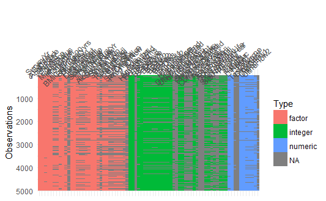

Visualize missing data

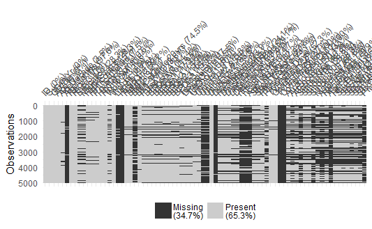

Clustered

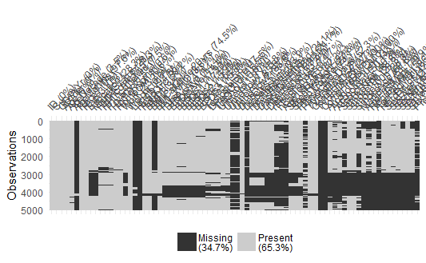

## Numerical EDA

### EDA with tables

#### Simple tables

##### One factor table

```r
table(NHANES$Gender)
```

```
female   male
  2495   2505
```

```r
table(NHANES$Education)
```

```
     8th Grade 9 - 11th Grade    High School   Some College   College Grad
           212            405            679           1160           1128
```

##### 2x2 tables

```r
table(NHANES$Gender, NHANES$Diabetes)
```

```
           No  Yes
  female 2291  175
  male   2272  198
```

Add margin totals

```r
addmargins(table(NHANES$Gender, NHANES$Diabetes))
```

```
           No  Yes  Sum
  female 2291  175 2466
  male   2272  198 2470
  Sum    4563  373 4936
```

Proportion table

```r
prop.table(table(NHANES$Gender, NHANES$Diabetes))
```

```
                 No        Yes
  female 0.46414100 0.03545381
  male   0.46029173 0.04011345
```

As percentage

```r
prop.table(table(NHANES$Gender, NHANES$Diabetes))*100
```

```
                No       Yes
  female 46.414100  3.545381
  male   46.029173  4.011345
```

```r
prop.table(table(NHANES$Gender, NHANES$Diabetes))*100
```

[output not shown]

Combining addmargins and prop.table

```r
addmargins(prop.table(table(NHANES$Gender, NHANES$Diabetes))*100)
```

```
             No    Yes    Sum
  female  46.41   3.55  49.96
  male    46.03   4.01  50.04
  Sum     92.44   7.56 100.00
```

##### N x N tables

```r
table(NHANES$Gender,  # rows
      NHANES$Education,  # columns
      NHANES$Diabetes) # factor
```

```
, ,  = No


         8th Grade 9 - 11th Grade High School Some College College Grad
  female        74            155         287          565          557
  male          94            211         304          478          497

, ,  = Yes


         8th Grade 9 - 11th Grade High School Some College College Grad
  female        17             19          51           50           27
  male          27             20          37           67           47
```

#### Other tables packages

With xtabs

```r
xtabs(~ Gender +
              Education +
              Diabetes,
      data=NHANES)
```

[output not shown]

With ftables

```r
ftable(NHANES$Gender,  # rows
      NHANES$Education,  # columns
      NHANES$Diabetes) # factor
```

```
                        No Yes

female 8th Grade        74  17
       9 - 11th Grade  155  19
       High School     287  51
       Some College    565  50
       College Grad    557  27
male   8th Grade        94  27
       9 - 11th Grade  211  20
       High School     304  37
       Some College    478  67
       College Grad    497  47
```

#### Nice Output tables

```r
CrossTable(NHANES$Gender, NHANES$Diabetes,
           digits = 2,
           prop.r = T, # If TRUE, row proportions will be included
           prop.c = T, # If TRUE, column proportions will be included
           prop.t = F, # If TRUE, table proportions will be included
           prop.chisq = FALSE, # If TRUE, chi-square contribution of each cell will be included
           chisq = TRUE, #If TRUE, the results of a chi-square test will be included
           dnn = c("Gender", "Diabetes"))
```

```
   Cell Contents
|-------------------------|
|                       N |
|           N / Row Total |
|           N / Col Total |
|-------------------------|


Total Observations in Table:  4936


             | Diabetes
      Gender |        No |       Yes | Row Total |
-------------|-----------|-----------|-----------|
      female |      2291 |       175 |      2466 |
             |      0.93 |      0.07 |      0.50 |
             |      0.50 |      0.47 |           |
-------------|-----------|-----------|-----------|
        male |      2272 |       198 |      2470 |
             |      0.92 |      0.08 |      0.50 |
             |      0.50 |      0.53 |           |
-------------|-----------|-----------|-----------|
Column Total |      4563 |       373 |      4936 |
             |      0.92 |      0.08 |           |
-------------|-----------|-----------|-----------|


Statistics for All Table Factors


Pearson's Chi-squared test
------------------------------------------------------------
Chi^2 =  1.49     d.f. =  1     p =  0.222

Pearson's Chi-squared test with Yates' continuity correction
------------------------------------------------------------
Chi^2 =  1.37     d.f. =  1     p =  0.243
```

### EDA with numerical summaries

For all variables

```r
summary(NHANES)
```

```
       ID           SurveyYr       Gender          Age         AgeDecade      AgeMonths         Race1
 Min.   :62163   2009_10:   0   female:2495   Min.   : 0.0    0-9   : 709   Min.   : 0     Black   : 589
 1st Qu.:64544   2011_12:5000   male  :2505   1st Qu.:17.0    10-19 : 704   1st Qu.: 4     Hispanic: 350
 Median :67039                                Median :36.0    50-59 : 690   Median :11     Mexican : 480
 Mean   :67028                                Mean   :36.7    20-29 : 672   Mean   :12     White   :3135
 3rd Qu.:69509                                3rd Qu.:54.0    40-49 : 670   3rd Qu.:20     Other   : 446
 Max.   :71915                                Max.   :80.0   (Other):1378   Max.   :23
                                                             NA's   : 177   NA's   :4882
      Race3               Education         MaritalStatus         HHIncome     HHIncomeMid        Poverty
 Asian   : 288   8th Grade     : 212   Divorced    : 352   more 99999 :1161   Min.   :  2500   Min.   :0
 Black   : 589   9 - 11th Grade: 405   LivePartner : 294   75000-99999: 524   1st Qu.: 30000   1st Qu.:1
 Hispanic: 350   High School   : 679   Married     :1896   25000-34999: 471   Median : 50000   Median :3
 Mexican : 480   Some College  :1160   NeverMarried: 737   35000-44999: 441   Mean   : 57078   Mean   :3
 White   :3135   College Grad  :1128   Separated   :  84   45000-54999: 373   3rd Qu.:100000   3rd Qu.:5
 Other   : 158   NA's          :1416   Widowed     : 222   (Other)    :1653   Max.   :100000   Max.   :5
                                       NA's        :1415   NA's       : 377   NA's   :377      NA's   :325
   HomeRooms      HomeOwn             Work          Weight          Length        HeadCirc        Height
 Min.   : 1.00   Own  :3076   Looking   : 166   Min.   :  3.6   Min.   : 50    Min.   :37     Min.   : 83.8
 1st Qu.: 4.00   Rent :1777   NotWorking:1413   1st Qu.: 55.4   1st Qu.: 78    1st Qu.:40     1st Qu.:156.5
 Median : 6.00   Other: 119   Working   :2263   Median : 72.1   Median : 88    Median :41     Median :165.6
 Mean   : 6.19   NA's :  28   NA's      :1158   Mean   : 70.3   Mean   : 86    Mean   :41     Mean   :161.5
 3rd Qu.: 8.00                                  3rd Qu.: 88.1   3rd Qu.: 97    3rd Qu.:42     3rd Qu.:174.2
 Max.   :13.00                                  Max.   :198.7   Max.   :112    Max.   :45     Max.   :200.4
 NA's   :28                                     NA's   :31      NA's   :4725   NA's   :4959   NA's   :159
      BMI          BMICatUnder20yrs         BMI_WHO         Pulse        BPSysAve      BPDiaAve       BPSys1
 Min.   :12.9   UnderWeight:  55    12.0_18.5   : 677   Min.   : 40   Min.   : 79   Min.   :  0   Min.   : 74
 1st Qu.:21.5   NormWeight : 805    18.5_to_24.9:1487   1st Qu.: 66   1st Qu.:107   1st Qu.: 62   1st Qu.:108
 Median :25.8   OverWeight : 193    25.0_to_29.9:1319   Median : 72   Median :116   Median : 69   Median :116
 Mean   :26.4   Obese      : 221    30.0_plus   :1338   Mean   : 74   Mean   :119   Mean   : 68   Mean   :119
 3rd Qu.:30.6   NA's       :3726    NA's        : 179   3rd Qu.: 82   3rd Qu.:128   3rd Qu.: 77   3rd Qu.:128
 Max.   :80.6                                           Max.   :136   Max.   :221   Max.   :116   Max.   :224
 NA's   :166                                            NA's   :718   NA's   :719   NA's   :719   NA's   :893
     BPDia1        BPSys2        BPDia2        BPSys3        BPDia3     Testosterone    DirectChol
 Min.   :  0   Min.   : 78   Min.   :  0   Min.   : 78   Min.   :  0   Min.   :   0   Min.   :0
 1st Qu.: 62   1st Qu.:106   1st Qu.: 62   1st Qu.:106   1st Qu.: 62   1st Qu.:  18   1st Qu.:1
 Median : 70   Median :116   Median : 70   Median :116   Median : 70   Median :  44   Median :1
 Mean   : 69   Mean   :119   Mean   : 68   Mean   :118   Mean   : 68   Mean   : 198   Mean   :1
 3rd Qu.: 78   3rd Qu.:128   3rd Qu.: 78   3rd Qu.:128   3rd Qu.: 78   3rd Qu.: 362   3rd Qu.:2
 Max.   :110   Max.   :226   Max.   :116   Max.   :216   Max.   :116   Max.   :1796   Max.   :4
 NA's   :893   NA's   :797   NA's   :797   NA's   :788   NA's   :788   NA's   :874    NA's   :775
```

[output cut: 33 more lines]

```
 Non-Smoker:2027   Min.   : 6     No  : 989   Min.   : 1     No  :1757    Min.   :10     No  :2333
 Smoker    :1560   1st Qu.:15     Yes :1454   1st Qu.:15     Yes : 686    1st Qu.:15     Yes : 549
 NA's      :1413   Median :17     NA's:2557   Median :16     NA's:2557    Median :17     NA's:2118
                   Mean   :18                 Mean   :17                  Mean   :18
                   3rd Qu.:19                 3rd Qu.:19                  3rd Qu.:19
                   Max.   :72                 Max.   :48                  Max.   :52
                   NA's   :3488               NA's   :3546                NA's   :4314
 SexEver         SexAge     SexNumPartnLife SexNumPartYear SameSex          SexOrientation  PregnantNow
 No  : 111   Min.   : 9     Min.   :   0    Min.   : 0     No  :2667   Bisexual    :  56   Yes    :  24
 Yes :2773   1st Qu.:15     1st Qu.:   2    1st Qu.: 1     Yes : 217   Heterosexual:2290   No     : 754
 NA's:2116   Median :17     Median :   5    Median : 1     NA's:2116   Homosexual  :  56   Unknown:  27
             Mean   :18     Mean   :  17    Mean   : 1                 NA's        :2598   NA's   :4195
             3rd Qu.:19     3rd Qu.:  12    3rd Qu.: 1
             Max.   :47     Max.   :2000    Max.   :69
             NA's   :2227   NA's   :2135    NA's   :2561
```

For one variable

```r
summary(NHANES$Age)
```

```
   Min. 1st Qu.  Median    Mean 3rd Qu.    Max.
    0.0    17.0    36.0    36.7    54.0    80.0
```

#### Create table summaries

| Gender | n | Mean age | SD |
| --- | --- | --- | --- |
| female | 2495 | 37.26733 | 22.88457 |
| male | 2505 | 36.15090 | 22.22623 |

| Gender | Mean age | SD | n | Percentage |
| --- | --- | --- | --- | --- |
| female | 37.26733 | 22.88457 | 2495 | 49.9 |
| male | 36.15090 | 22.22623 | 2505 | 50.1 |

#### Advanced tables

Two tipes of variables - one - many

Two types of functions - one - many

|  |  | Functions |  |
| --- | --- | --- | --- |
|  |  | one | many |
| Variables | one | mtcars %>%,summarise (mean_mpg = mean(mpg)) | mtcars %>%,summarise (min_mpg = min(mpg), max_mpg = max(mpg)) |
|  | many | mtcars %>%,summarise(mean_mpg = mean(mpg), mean_disp = mean(disp)) | mtcars %>%,summarise(min_mpg = min(mpg) , min_disp = min(disp), max_mpg = max(mpg) , max_disp = max(disp)) |

## Visual EDA

### Continuous data

#### One variable

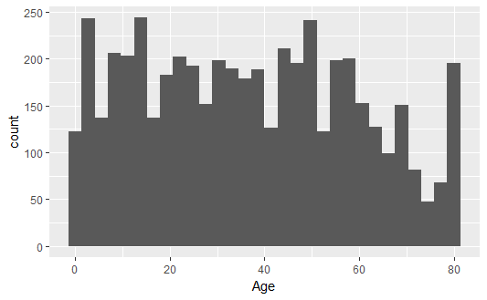

Change the bins

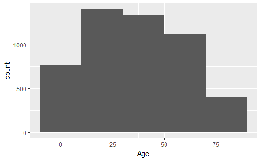

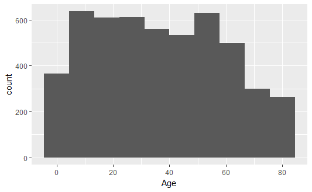

#### Two variables

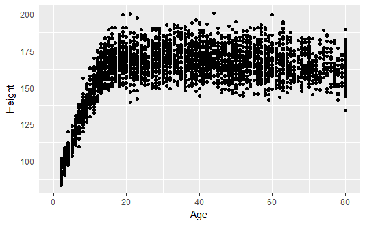

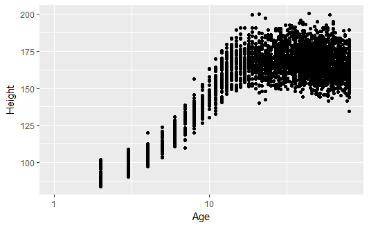

#### More than two variables

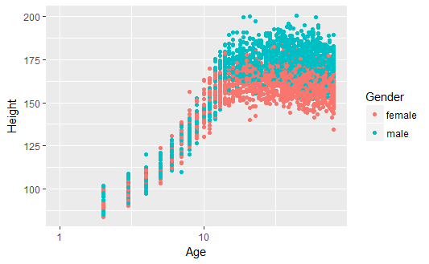

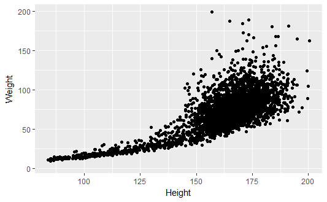

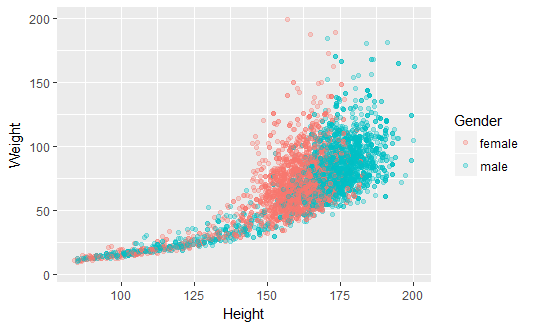

Now prepare for publication

[figure not shown]

### Categorical data

#### Barplots

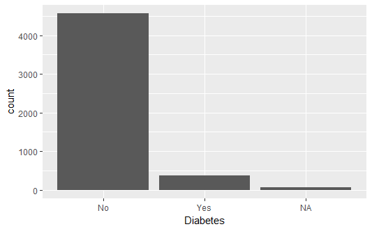

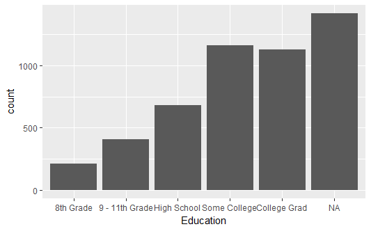

Flip categories

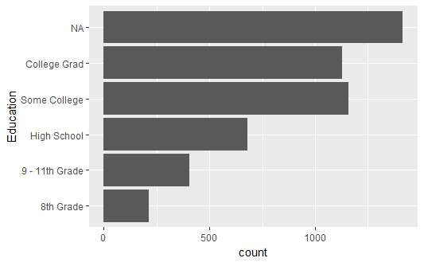

Eliminate NAs

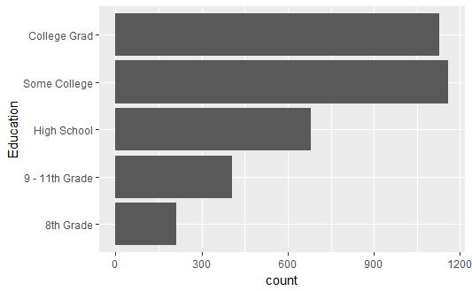

Add a factor

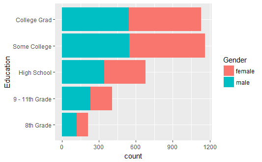

Nicely formated

[figure not shown]

#### By groups

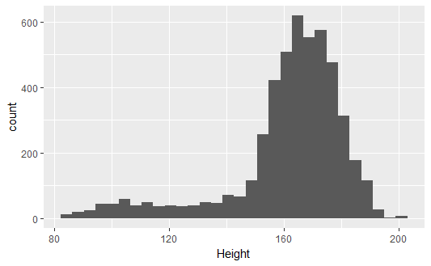

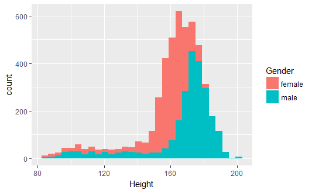

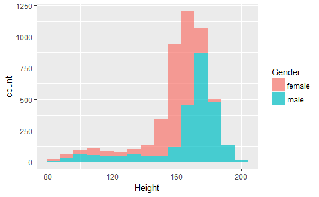

### Continuous and categorical

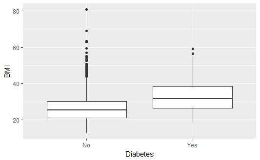

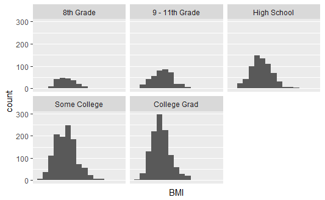

#### Boxplots

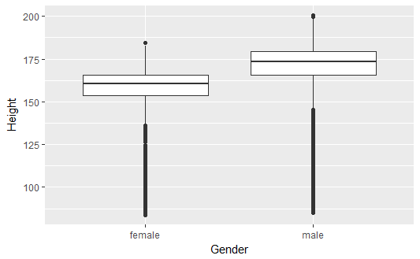

Dirty option: limit the coordinates

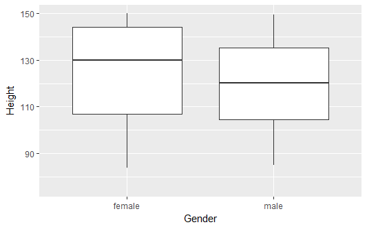

More elegant solution, with R Base

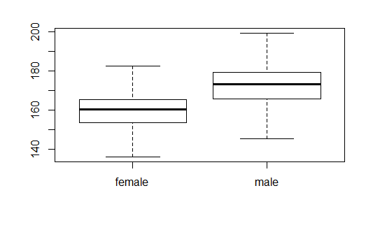

#### Categorical data independence

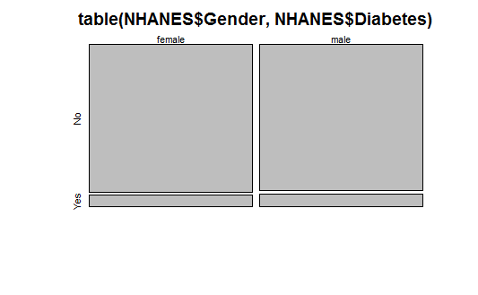

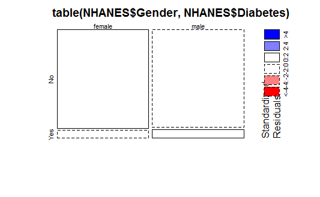

Exploring some associations

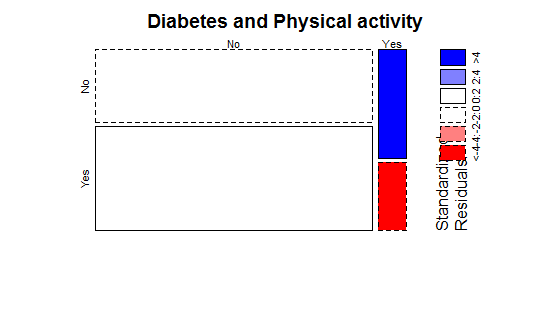

# Recapitulation

What we learned

- explore datasets
- summarise datasets or variables
- find NA values
- create summary tables
- create visualizations of categorical, continuous or both data

# Advanced data manipulation

## Create variables

mutate